# Econ 522 - PS2

Bruk Esayas

**GitHub repo:** https://github.com/00bruk/ec522_ps2_esayas

## 1. Data

This dataset, sourced from FRED, includes monthly UE rates (%) for the US: Oregon, California, Texas, and New York from January 1976 to present.

```r
head(unemp_raw)
```

```
## # A tibble: 6 × 3
##   symbol date       price
##   <chr>  <date>     <dbl>
## 1 UNRATE 1976-01-01   7.9
## 2 UNRATE 1976-02-01   7.7
## 3 UNRATE 1976-03-01   7.6
## 4 UNRATE 1976-04-01   7.7
## 5 UNRATE 1976-05-01   7.4
## 6 UNRATE 1976-06-01   7.6
```

## 2. Wrangling

This table includes a summary of the unemployment rate over the 5 states. The first 2 tables includes the minimum, mean, and maximum rates for the full sample (from 1976- Present) and the recent sample (2015-Present). The last 2 tables shows the more extreme month-over-month increases and decreases (not including 2020 in order to remove pandemic-related noise).

Full Sample Summary

| region | mean_rate | min_rate | max_rate |
| --- | --- | --- | --- |
| California | 7.07 | 3.8 | 16.1 |
| New York | 6.35 | 3.8 | 16.7 |
| Oregon | 6.66 | 3.4 | 13.7 |
| Texas | 5.85 | 3.4 | 12.8 |
| United States | 6.05 | 3.4 | 14.8 |

Recent Sample Summary (2015-Present)

| region | mean_rate | min_rate | max_rate |
| --- | --- | --- | --- |
| California | 5.63 | 3.8 | 16.1 |
| New York | 5.10 | 3.8 | 16.7 |
| Oregon | 4.75 | 3.4 | 13.7 |
| Texas | 4.58 | 3.4 | 12.8 |
| United States | 4.62 | 3.4 | 14.8 |

Top 5 Increases (Excluding 2020)

| symbol | date | unemployment_rate | region | unemployment_rate_change |
| --- | --- | --- | --- | --- |
| TXUR | 2009-05-01 | 7.6 | Texas | 1.1 |
| ORUR | 2008-12-01 | 8.9 | Oregon | 0.7 |
| ORUR | 2008-11-01 | 8.2 | Oregon | 0.7 |
| ORUR | 2009-01-01 | 9.6 | Oregon | 0.7 |
| ORUR | 1980-03-01 | 7.4 | Oregon | 0.6 |
| UNRATE | 1980-04-01 | 6.9 | United States | 0.6 |

Top 5 Decreases (Excluding 2020)

| symbol | date | unemployment_rate | region | unemployment_rate_change |
| --- | --- | --- | --- | --- |
| UNRATE | 1983-07-01 | 9.4 | United States | -0.7 |
| NYUR | 2021-09-01 | 6.2 | New York | -0.6 |
| ORUR | 1977-05-01 | 7.8 | Oregon | -0.5 |
| CAUR | 2021-07-01 | 7.4 | California | -0.5 |
| CAUR | 2021-09-01 | 6.5 | California | -0.5 |
| NYUR | 2021-07-01 | 7.0 | New York | -0.5 |
| UNRATE | 2010-12-01 | 9.3 | United States | -0.5 |
| UNRATE | 2014-04-01 | 6.2 | United States | -0.5 |
| UNRATE | 2021-07-01 | 5.4 | United States | -0.5 |

## 3. Visualization

The figures visualize UE trends across our 5 states. Including: a combined line plot, a faceted line plot by region, a bar chart of mean rates, and a choice plot of month-to-month variations.

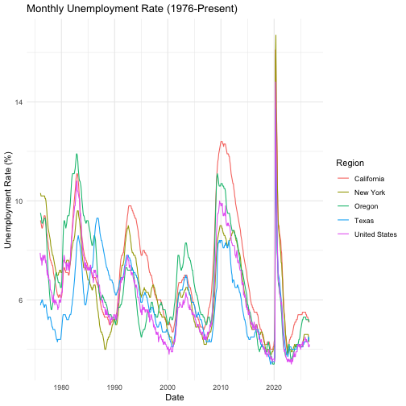

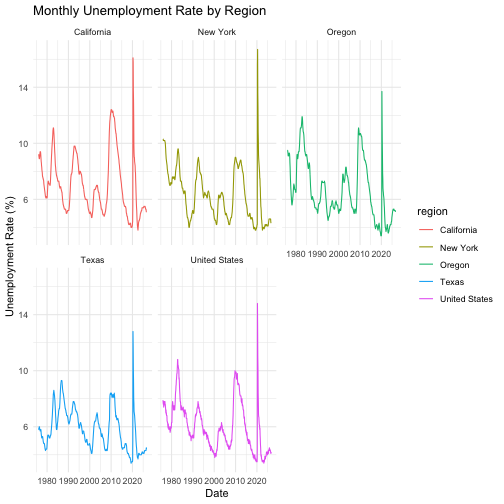

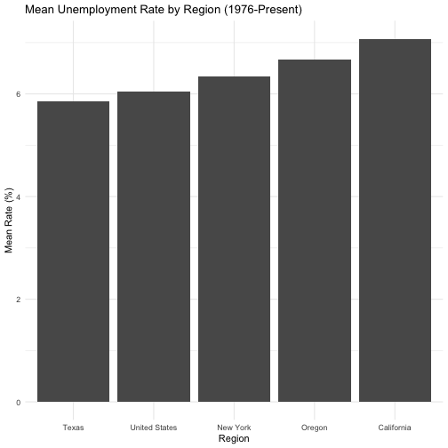

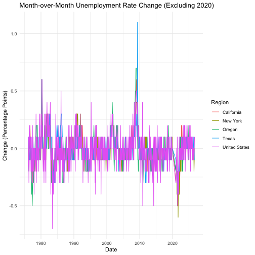

Note: This choice plot shows month-to-month volatility in regional UE rates. We remove 2020 in order to remove any distortions in the data caused by the pandemic.

## 4. Reflection

The most challenging parts of this data set was getting git connected to github and trying to troubleshoot the FRED API connection blocks. Using the terminal to clone, commit, and push took a few attempts before I finally got the hang of it. The most straightforward part was probably the data extraction and ggplot visualization portion of the project. All in all, I definetely feel more comfortable running git commits mid-project in comparison to when I first started.